# hw1

John Peng

This data set(firms) comprises a set of companies and looks at their industry(industry.recode), employee size(empsize), and assets(assets).

**Plotting # of employees x assets**

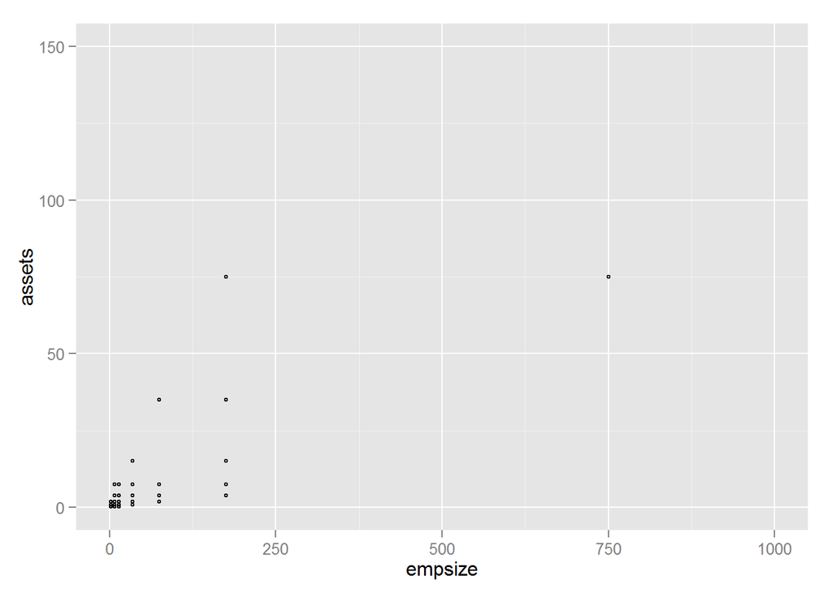

**Hiding outlier by adjusting plot limits**

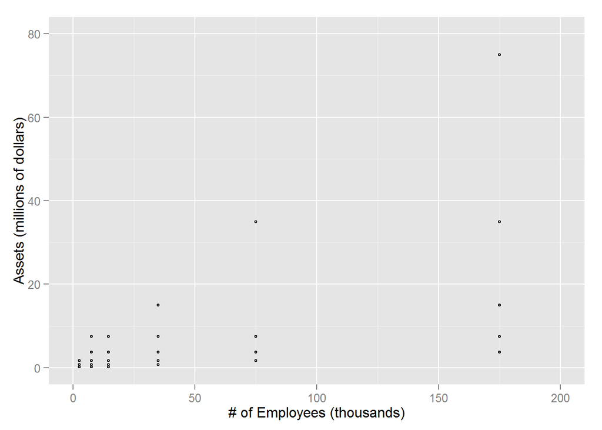

**Zooming in on clustered data points at lower values**

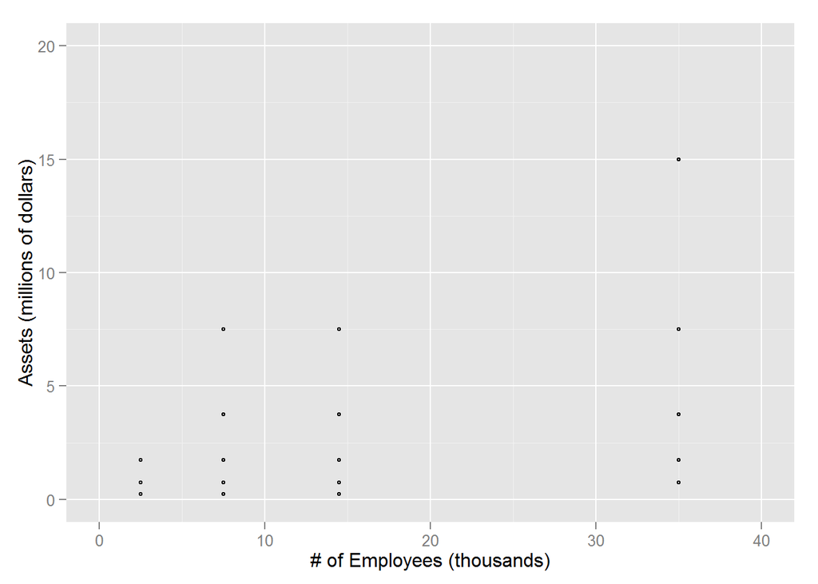

- Number of employees does not seem to be a very accurate indicator of assets, but it does seem to be an indicator of the maximum assets for a company of that size, since the highest asset company is increasing as number of employees increasing. This is possibly due to the lack of success of a high proportion of companies across all employee sizes. However, a more detailed analysis would be needed to determine if there is or isn’t an association for these variables.

**Barplot of industry breakdown for businesses**

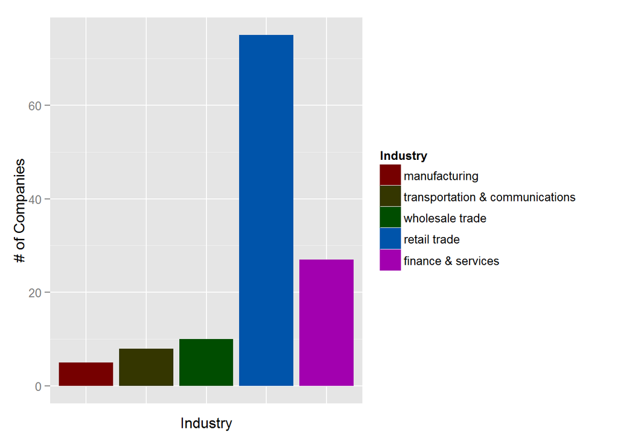

- Most of the companies in the sample are in retail trade plus finance & services. It would be interesting to see in future analyses whether the high proportion of low-asset companies is due to this. Perhaps the assets of the businesses in some or one of these areas are especially volatile.

**Density plot of company assets distribution**

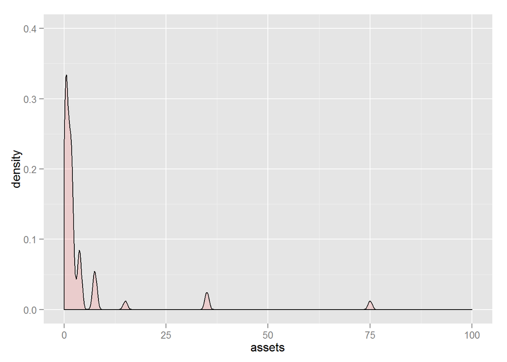

- A large proportion of companies in the sample have assets below $10 million.